# Week 2, day 2

## hw2: text-mining

**Hao-Chien Wang**  
In this assignment, I want to analyze the terms that are used on the *HatePolitics* forum at `ptt`. I separate the whole assignments into several files and save the results from every Rscripts so I don’t have to run everything everytime.

### Crawler

First, I use a crawler to grab all texts from the website. The first step is to get all links to the pages that contain the target text, and the second step is to save the text into files and separate them by year posted.

```r
library(bitops)
library(httr)
library(RCurl)
library(XML)
library(bitops)
library(tm)
library(NLP)
library(tmcn)
library(jiebaRD)
library(jiebaR)
library(dplyr)

#crawler to grab the links
setwd("/home/fhcwcsy/Documents/summerproj/data_science_programming/week_2/day2")
prefix = "https://www.ptt.cc/bbs/HatePolitics/index"
link = list()
for (id in c(1:500)) {
    url = paste0( prefix, as.character(id), ".html" )
    html = htmlParse( GET(url) )
    url.list = xpathSApply( html, "//div[@class='title']/a[@href]", xmlAttrs )
    link = rbind( link, as.matrix(paste('https://www.ptt.cc', url.list, sep='')) )
}
link <- unlist(link)
head(link)
# write.csv( data, file = "./link.csv" )

# crawler to get the actual text
getdoc = function(url)
{
    html = GET( url ) %>%
        htmlParse()
    doc = xpathSApply( html, "//div[@id='main-content']", xmlValue )
    time = xpathSApply( html, "//*[@id='main-content']/div[4]/span[2]", xmlValue )
    temp = gsub( "  ", " 0", time )
    try({
    part = strsplit( temp, split=" ", fixed=T )[[1]]
    # month = part[[1]][2]
    # day = as.numeric(part[[1]][3])
    year = part[5]
    fileName <- paste0('./data/', year, ".txt")
    write(doc, fileName, append = TRUE)
    })
}

sapply(link, getdoc)
```

Note: I actually ran 9 crawlers at a time because it is found that running many crawlers simutaneously does not slow down individual progress. I crawl every single posts on the forum. The code above is actually only the first crawler. A part of the result is shown below:

```r
library(dplyr)
readChar("./data/2016.txt", file.info("./data/2016.txt")$size) %>%
  str(nchar.max = 2000)
```

```
##  chr "作者ChenDotQ (好人好事代表 no.4440337)看板HatePolitics標題[黑特] 一些五四三的廢話時間Fri Jan  1 22:36:34 2016\n\n\n\n        KMT真的很智障，聲勢已經低到不能再低了\n\n然後弄一個「換柱大會」  秀了一次下限\n\n接著整個政黨好像以KMT為恥一樣，候選人的文宣連黨徽也不敢秀\n\n真的很可笑。 我認為一個政黨一定有他做得好與做不好的地方\n\n如果連最基本的自我認同就辦不到了，這樣誰敢投呀?  見鬼了......\n\n\n\n       朱立倫也真是白痴，選不贏還出來選，不能因為為阿嬤的一句…
```

### Generate TDM

Before generating TDM, I wrote another crawler to grab the names of popular political figures from [here](https://dailyview.tw/top100/topic/9?volumn=1&page=1):

```r
library(dplyr)
library(rvest)
setwd("/home/fhcwcsy/Documents/summerproj/data_science_programming/week_2/day2")
name = c()
for (i in c(1:20)) {
    newName = paste0("https://dailyview.tw/top100/topic/9?volumn=1&page=", i) %>%
        read_html %>%
        html_nodes("#volume_rank .text-left") %>%
        html_text
    name = c( name, newName)
}

head( name, n = 20)
```

```
##  [1] "韓國瑜" "蔡英文" "柯文哲" "郭台銘" "賴清德" "陳水扁" "蘇貞昌"
##  [8] "朱立倫" "陳菊"   "王金平" "馬英九" "吳敦義" "陳其邁" "黃國昌"
## [15] "盧秀燕" "王世堅" "羅智強" "鄭麗君" "黃捷"   "余天"
```

```r
write.csv( name, file = "./name.csv" )
```

Also I downloaded a csv containing names of towns in Taiwan. After some rearrangements, I can add those terms to the cutter.

```r
library(dplyr)

setwd("/home/fhcwcsy/Documents/summerproj/data_science_programming/week_2/day2")
#read downloaded csv file
rawPlaces = read.csv( file = "./town.csv", head = TRUE )

#combine county names and town names into a vector
nameOfPlaces = c( levels(rawPlaces[,1]), levels(rawPlaces[,2]) )

#add the names without suffixes as new elements
nameOfPlaces = c(nameOfPlaces, gsub("鄉", "", nameOfPlaces), gsub("鎮", "", nameOfPlaces), gsub("市", "", nameOfPlaces), gsub("縣", "", nameOfPlaces), gsub("區", "", nameOfPlaces) )

#character variations
nameOfPlaces = c( nameOfPlaces, gsub("臺", "台", nameOfPlaces))

#remove redundancy
nameOfPlaces = levels( factor( nameOfPlaces))

#result
head(nameOfPlaces, 20)
```

```
##  [1] "七堵"     "七堵區"   "七美"     "七美鄉"   "七股"     "七股區"
##  [7] "三地門"   "三地門鄉" "三峽"     "三峽區"   "三星"     "三星鄉"
## [13] "三灣"     "三灣鄉"   "三義"     "三義鄉"   "三芝"     "三芝區"
## [19] "三重"     "三重區"
```

```r
#write result
write.csv( nameOfPlaces, file = "./name_of_places.csv" )
```

Now, I can use `jieba` to cut the files into words and generate TDM.

```r
library(bitops)
library(httr)
library(RCurl)
library(XML)
library(bitops)
library(tm)
library(NLP)
library(tmcn)
library(jiebaRD)
library(jiebaR)
library(dplyr)


setwd("/home/fhcwcsy/Documents/summerproj/data_science_programming/week_2/day2")
#load word data by files into a list
d.corpus = Corpus( DirSource("./data") )
#remove punctuation and numbers
d.corpus = tm_map(d.corpus, removePunctuation)
d.corpus = tm_map(d.corpus, removeNumbers)
d.corpus = tm_map(d.corpus, function(word)
{
    gsub("[A-Za-z0-9]", "", word)
})

#generate text matrix
cutter = worker()

myName = rbind(read.csv("./name_of_places.csv", skip = 1, header = FALSE), read.csv("./name.csv", skip = 1, header = FALSE) )
myName = myName[,2] %>%
    levels
new_user_word( cutter, myName )
```

```
## [1] TRUE
```

```r
#define custom cutter
jieba_tokenizer = function(d)
{
    unlist( segment( d[[1]], cutter ) )
}

#cut, return a list
seg = lapply(d.corpus, jieba_tokenizer)

#use `table` to count the words then transform it into a df
count_token = function(d)
{
    as.data.frame(table(d))
}
tokens = lapply( seg, count_token )

n = length(seg)
tdm = tokens[[1]]
colNames = names(seg)
colNames = gsub(".txt", "", colNames)

for( id in c(2:n) )
{
  # d: the words
  tdm = merge(tdm, tokens[[id]], by="d", all = TRUE)
  names(tdm) = c('d', colNames[1:id])
}
# use is.na to pick up NAs and assign value 0 to all NAs
tdm[is.na(tdm)] <- 0
library(knitr)
# result output
kable(tail(tdm))
```

|  | d | 2006 | 2007 | 2008 | 2009 | 2010 | 2011 | 2012 | 2013 | 2014 | 2015 | 2016 | 2017 | 2018 | 2019 |
| --- | --- | --- | --- | --- | --- | --- | --- | --- | --- | --- | --- | --- | --- | --- | --- |
| 522998 |  | 0 | 0 | 0 | 0 | 0 | 0 | 0 | 0 | 0 | 0 | 0 | 0 | 0 | 1 |
| 522999 |  | 0 | 0 | 0 | 0 | 0 | 0 | 0 | 0 | 0 | 0 | 0 | 0 | 0 | 1 |
| 523000 |  | 0 | 0 | 0 | 0 | 0 | 0 | 0 | 0 | 0 | 0 | 0 | 0 | 0 | 2 |
| 523001 |  | 0 | 0 | 0 | 0 | 0 | 0 | 0 | 0 | 0 | 0 | 0 | 0 | 0 | 1 |
| 523002 |  | 0 | 0 | 0 | 0 | 0 | 0 | 0 | 0 | 0 | 0 | 0 | 0 | 0 | 1 |
| 523003 | ﬊ | 0 | 0 | 0 | 0 | 0 | 0 | 0 | 0 | 0 | 0 | 0 | 0 | 0 | 1 |

```r
kable(head(tdm))
```

| d | 2006 | 2007 | 2008 | 2009 | 2010 | 2011 | 2012 | 2013 | 2014 | 2015 | 2016 | 2017 | 2018 | 2019 |
| --- | --- | --- | --- | --- | --- | --- | --- | --- | --- | --- | --- | --- | --- | --- |
|  | 3338 | 6127 | 2723 | 37 | 70 | 325 | 123 | 942 | 6158 | 1349 | 1589 | 727 | 1206 | 41345 |
| ﹌ | 2 | 5 | 0 | 0 | 2 | 0 | 0 | 2 | 7 | 1 | 0 | 0 | 0 | 67 |
| ﹋ | 2 | 3 | 0 | 0 | 0 | 0 | 0 | 2 | 3 | 1 | 0 | 0 | 0 | 163 |
| ﹏ | 17 | 6 | 11 | 0 | 5 | 0 | 0 | 4 | 5 | 2 | 3 | 0 | 0 | 82 |
| ︳ | 17 | 2 | 0 | 0 | 1 | 0 | 0 | 0 | 0 | 0 | 0 | 0 | 0 | 12 |
| ︱ | 16 | 83 | 13 | 0 | 1 | 5 | 1 | 0 | 2 | 0 | 1 | 0 | 0 | 258 |

```r
write.csv(tdm, file = "./tdm.csv")
```

### Calculate TF_IDF

```r
library(bitops)
library(httr)
library(RCurl)
library(XML)
library(bitops)
library(tm)
library(NLP)
library(tmcn)
library(jiebaRD)
library(jiebaR)
library(dplyr)
library(knitr)

setwd("/home/fhcwcsy/Documents/summerproj/data_science_programming/week_2/day2")
tdm_raw = read.csv( file = "./tdm.csv", header = TRUE )
tdm = tdm_raw
n = length(tdm)
tf = apply(as.matrix(tdm[,3:n]), 2, sum) #total number of words in every documents
idfCal = function(doc) #calculate idf
{
    log2( (length(doc) ) / Matrix::nnzero(doc) )
}
idf = apply(as.matrix(tdm[,3:n]), 1, idfCal)

tfidfMat = as.matrix(tdm[,2:n])
# tf-idf = elements * idf / tf(it's value is now the total number of words in every documents)
# define functions to calculate tf-idf (two steps)
tfidfCal1 = function(col)
{
  as.numeric(col) * idf
}
tfidfCal2 = function(row)
{
  row / tf
}
# save the word column since they will be lost later
wordscol = tfidfMat[, 1]
# calculate with two applys
tfidfMat = apply(tfidfMat[, 2:ncol(tfidfMat)], 2, tfidfCal1)
tfidfMat = apply(tfidfMat, 1, tfidfCal2)
tfidfMat = t(tfidfMat)
# restore the words
rownames( tfidfMat) = wordscol
#step result
str(tfidfMat)
```

```
##  num [1:523003, 1:14] 0.00 7.89e-06 9.64e-06 4.27e-05 1.21e-04 ...
##  - attr(*, "dimnames")=List of 2
##   ..$ : chr [1:523003] "　" "﹌" "﹋" "﹏" ...
##   ..$ : chr [1:14] "X2006" "X2007" "X2008" "X2009" ...
```

```r
# remove trash words
stopLine = rowSums(tfidfMat)
delId = which(stopLine == 0) # adjust the condition if the result is not satisfying
tdm = tdm[-delId,]
tfidfMat = tfidfMat[-delId,]
colnames(tfidfMat) = gsub("X", "", colnames(tfidfMat))
colnames(tdm) = gsub("X", "", colnames(tdm))

# rank
rank = function(col) {rownames(tfidfMat)[order(-col)][1:30]}
rank = apply( tfidfMat, 2, rank )
str(rank)
```

```
##  chr [1:30, 1:14] "明禁黨" "蔡起方" "天賜" "國務" "粘貼" "機要" "甲君" ...
##  - attr(*, "dimnames")=List of 2
##   ..$ : NULL
##   ..$ : chr [1:14] "2006" "2007" "2008" "2009" ...
```

```r
#save progress
write.csv(rank, file = "./rank.csv")
write.csv(tdm, file = "./tdm_new.csv")
write.csv(tfidfMat, file = "./tfidf.csv")
```

### Plot

I plot the number of posts (estimated by the size of files) and found that the number of posts rocketed during this year. Therefore, I have to normalize the count of each words when I plot the most popular words. In the second plot, we can see that some terms became popular recently while others have already been discussed for years. Note that the words that equally appear in every posts have been removed during the `TF_IDF` process.

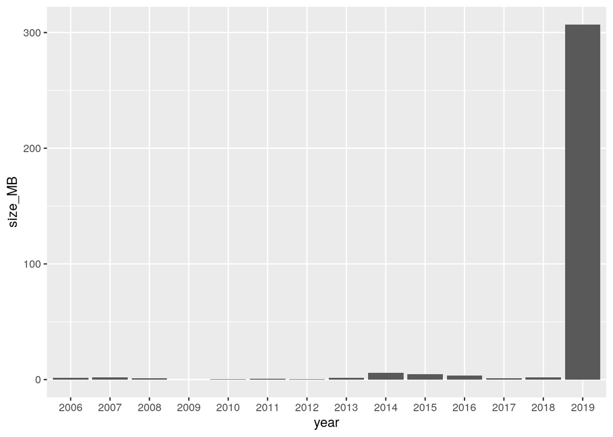

```r
library(ggplot2)
library(dplyr)

setwd("/home/fhcwcsy/Documents/summerproj/data_science_programming/week_2/day2")

tdm_raw = read.csv( file = "./tdm_new.csv")
rank_raw = read.csv( file = "./rank.csv")
tfidf_raw = read.csv( file = "./tfidf.csv")

#total amount of posts by year
year = gsub( "X", "", colnames(rank_raw)[2:(ncol(rank)+1)] )
fileName = paste0( "./data/", year, ".txt")
size_MB = sapply(fileName, file.size) /(1024^2)
sizedf = data.frame(year, size_MB)
ggplot(sizedf, aes(x = year, y = size_MB)) + geom_bar(stat="identity")
```

```r
#find the trends of the top words this year
tdm = select(tdm_raw, 3:ncol(tdm_raw))
colnames(tdm) = c("word", year)
tdm = arrange(tdm, desc(tdm[,'2019'])) %>%
  filter( nchar(as.character(word)) != 1 & as.character(word) != "網址")
str(tdm)
```

```
## 'data.frame':    514617 obs. of  15 variables:
##  $ word: Factor w/ 521516 levels "﹌","﹋","﹉",..: 497998 501552 257201 394491 276175 258220 470834 498411 472246 430199 ...
##  $ 2006: int  1 3 0 0 46 0 1 2 0 0 ...
##  $ 2007: int  1 2 0 0 76 1 4 0 2 7 ...
##  $ 2008: int  0 0 0 10 29 0 0 0 0 8 ...
##  $ 2009: int  0 0 0 15 7 0 0 0 0 1 ...
##  $ 2010: int  0 0 0 26 0 0 3 0 1 3 ...
##  $ 2011: int  0 0 0 73 27 0 0 0 0 2 ...
##  $ 2012: int  0 0 0 32 3 0 0 0 1 1 ...
##  $ 2013: int  0 0 10 32 108 0 2 0 0 11 ...
##  $ 2014: int  1 0 339 184 218 1 9 0 13 45 ...
##  $ 2015: int  0 0 178 646 635 4 3 0 0 84 ...
##  $ 2016: int  0 1 158 339 308 14 4 0 3 31 ...
##  $ 2017: int  21 0 66 175 72 11 9 0 1 18 ...
##  $ 2018: int  391 52 285 134 414 107 0 17 2 102 ...
##  $ 2019: int  115854 88007 72667 60924 59519 39326 28254 27934 24081 22894 ...
```

```r
#normalize/rescale
normalize = function(row)
{
  row / size_MB * 1000
}
word_tmp = tdm[,1]
tdm_normalized = t(apply(tdm[,2:(ncol(tdm))], 1, normalize))
rownames(tdm_normalized) = word_tmp
str(tdm_normalized)
```

```
##  num [1:514617, 1:14] 588 1763 0 0 27028 ...
##  - attr(*, "dimnames")=List of 2
##   ..$ : chr [1:514617] "韓國瑜" "韓粉" "柯文哲" "蔡英文" ...
##   ..$ : chr [1:14] "2006" "2007" "2008" "2009" ...
```

```r
#plot the popularity of the most popular words in 2019
topten = tdm_normalized[1:10,]
kable(topten)
```

|  | 2006 | 2007 | 2008 | 2009 | 2010 | 2011 | 2012 | 2013 | 2014 | 2015 | 2016 | 2017 | 2018 | 2019 |
| --- | --- | --- | --- | --- | --- | --- | --- | --- | --- | --- | --- | --- | --- | --- |
| 韓國瑜 | 587.5666 | 518.4872 | 0.000 | 0.000 | 0.00 | 0.000 | 0.000 | 0.000 | 169.8116 | 0.0000 | 0.0000 | 18749.6507 | 200280.112 | 377306.09 |
| 韓粉 | 1762.6997 | 1036.9743 | 0.000 | 0.000 | 0.00 | 0.000 | 0.000 | 0.000 | 0.0000 | 0.0000 | 298.9513 | 0.0000 | 26635.718 | 286615.72 |
| 柯文哲 | 0.0000 | 0.0000 | 0.000 | 0.000 | 0.00 | 0.000 | 0.000 | 7114.165 | 57566.1361 | 36733.0691 | 47234.3113 | 58927.4736 | 145984.225 | 236657.36 |
| 蔡英文 | 0.0000 | 0.0000 | 7480.713 | 120274.369 | 92973.13 | 114566.910 | 75255.582 | 22765.328 | 31245.3364 | 133312.1497 | 101344.5033 | 156247.0890 | 68638.197 | 198413.49 |
| 民調 | 27028.0622 | 39405.0246 | 21694.067 | 56128.039 | 0.00 | 42374.063 | 7055.211 | 76832.983 | 37018.9312 | 131042.1286 | 92077.0118 | 64284.5166 | 212061.295 | 193837.77 |
| 柯粉 | 0.0000 | 518.4872 | 0.000 | 0.000 | 0.00 | 0.000 | 0.000 | 0.000 | 169.8116 | 825.4622 | 4185.3187 | 9821.2456 | 54808.112 | 128074.47 |
| 郭台銘 | 587.5666 | 2073.9487 | 0.000 | 0.000 | 10727.67 | 0.000 | 0.000 | 1422.833 | 1528.3045 | 619.0967 | 1195.8053 | 8035.5646 | 0.000 | 92015.87 |
| 韓導 | 1175.1331 | 0.0000 | 0.000 | 0.000 | 0.00 | 0.000 | 0.000 | 0.000 | 0.0000 | 0.0000 | 0.0000 | 0.0000 | 8707.831 | 90973.71 |
| 郭董 | 0.0000 | 1036.9743 | 0.000 | 0.000 | 3575.89 | 0.000 | 2351.737 | 0.000 | 2207.5509 | 0.0000 | 896.8540 | 892.8405 | 1024.451 | 78425.50 |
| 賴清德 | 0.0000 | 3629.4102 | 5984.570 | 8018.291 | 10727.67 | 3138.819 | 2351.737 | 7825.582 | 7641.5225 | 17334.7068 | 9267.4914 | 16071.1292 | 52246.986 | 74559.75 |

```r
library(reshape2)
#melt the df so that ggplot can read the data
topten_melted = melt(t(topten))
colnames(topten_melted) = c("year", "word", "normalized_frequency")
head(topten_melted)
```

```
##   year   word normalized_frequency
## 1 2006 韓國瑜             587.5666
## 2 2007 韓國瑜             518.4872
## 3 2008 韓國瑜               0.0000
## 4 2009 韓國瑜               0.0000
## 5 2010 韓國瑜               0.0000
## 6 2011 韓國瑜               0.0000
```

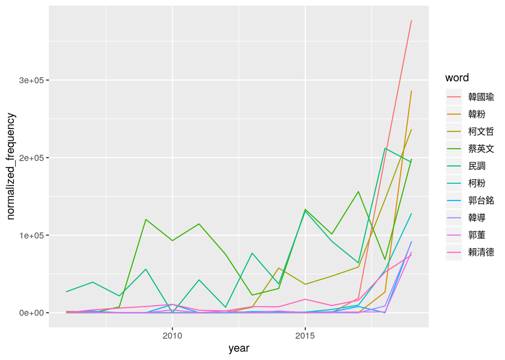

```r
ggplot(topten_melted, aes( year, normalized_frequency)) + geom_line(aes(color = word))
```